# Task_A_Piechocka

Agnieszka Piechocka

5 lutego 2018

## REPORT

The main goal of this report is to analyse data about Pearson e-learning platform for English language learners and suggest changes than can improve it.

The first and the most basic step is just to summarise every column of data we have.

```
##  ď.żlearner_id        country      in_course      unit
##  Min.   :     39   TR     :52710   f: 6100   1      :11407
##  1st Qu.:1044868   ES     : 8409   t:75332   2      : 9244
##  Median :1092947   PL     : 5948             3      : 8160
##  Mean   :1137218   CO     : 5537             4      : 7154
##  3rd Qu.:1244460   IT     : 1779             5      : 6448
##  Max.   :1390141   OM     :  856             6      : 5912
##  NA's   :17        (Other): 6193             (Other):33107
##    avg_score        completion        inv_rate
##  Min.   :0.0000   Min.   :0.0250   Min.   :0.00000
##  1st Qu.:0.7170   1st Qu.:0.7000   1st Qu.:0.00000
##  Median :0.8390   Median :0.9620   Median :0.00000
##  Mean   :0.7922   Mean   :0.8098   Mean   :0.04447
##  3rd Qu.:0.9300   3rd Qu.:1.0000   3rd Qu.:0.02300
##  Max.   :3.0000   Max.   :1.0000   Max.   :2.00000
##  NA's   :5                         NA's   :5
```

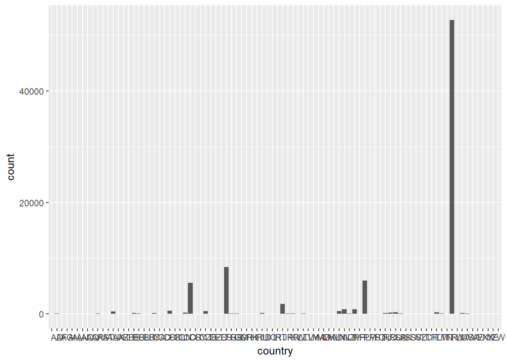

There is a huge demand for this platform in Turkey. It may be a good idea to try to customize the platform for their needs and interest – e.g. articles in reading comprehension tasks about cooperation between Turkey and United Kingdom. In the future it could be done for other countries as well.

First we try to find a connection between data.

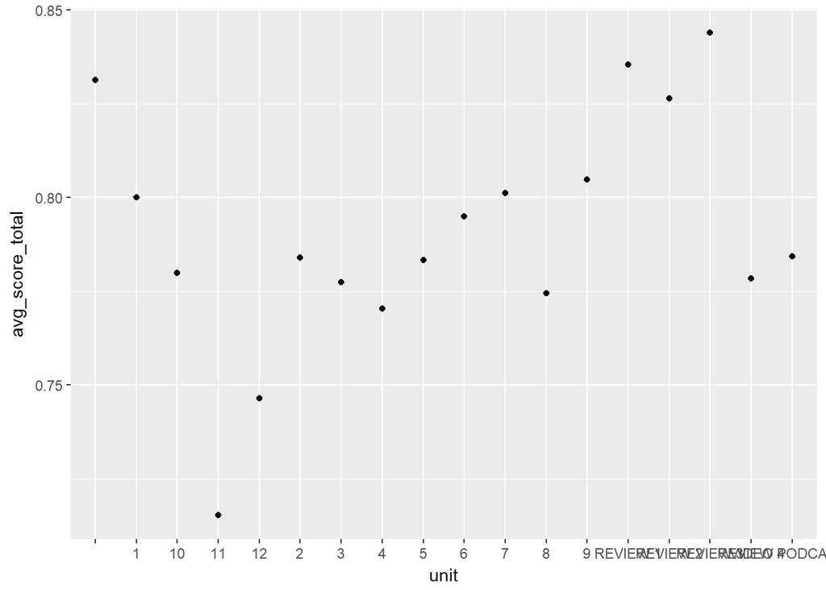

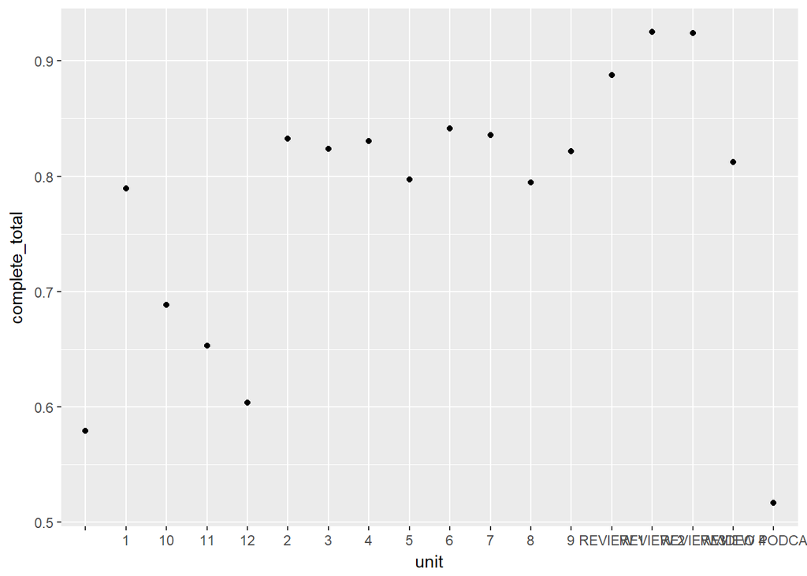

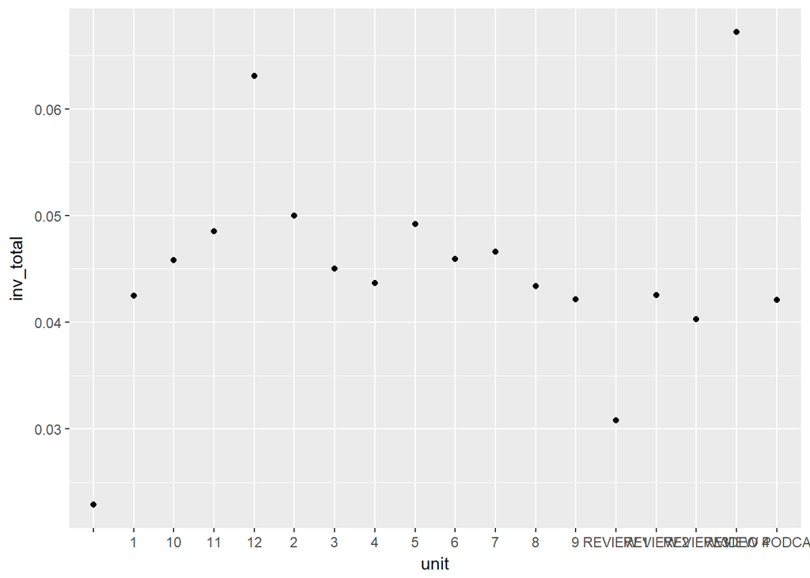

As the graphs above are not very informative, we are setting values, which will stand for a minimum for being considered as a high value (0.8 for average score and completion, inverse order equal 0). From them we can easily draw conclusions.

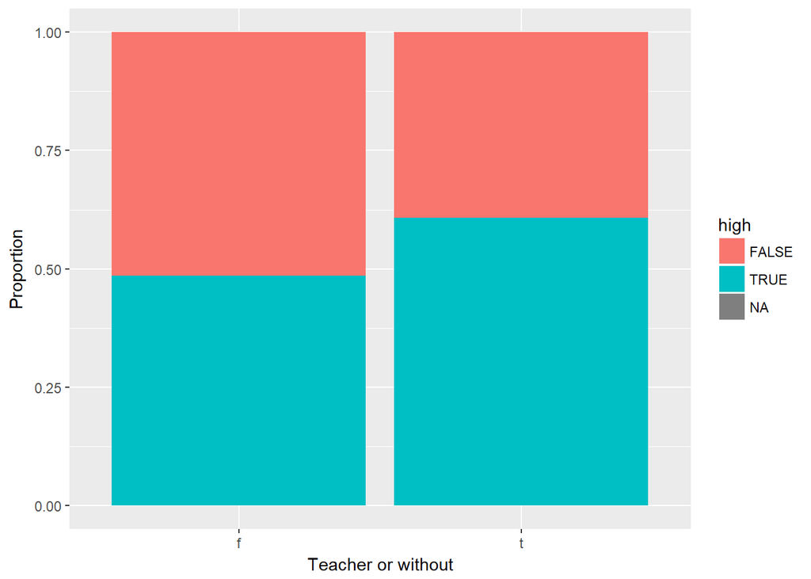

Students with teachers achieve high average of scores more often that students studying on their own. It may be a good idea to prepare online classes - videos when teachers are explaining some more difficult matters so individual users can benefit from them.

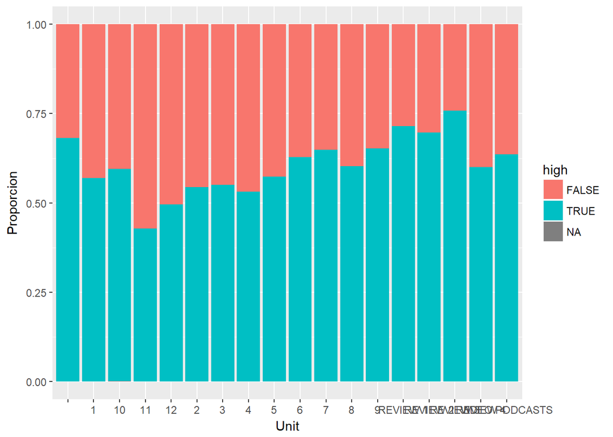

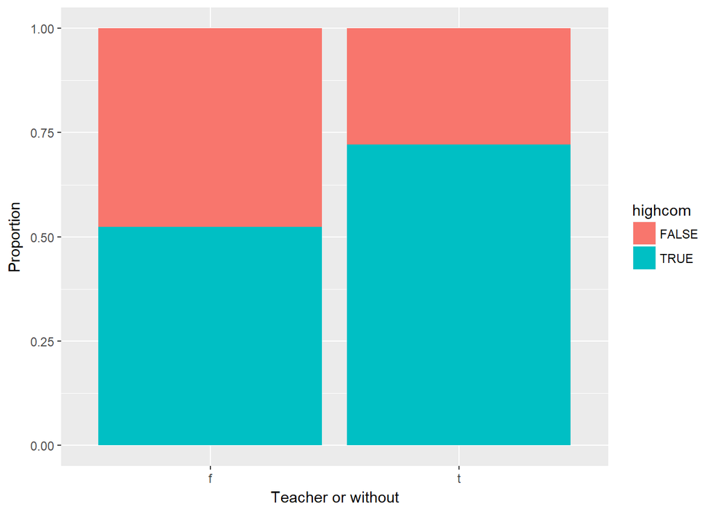

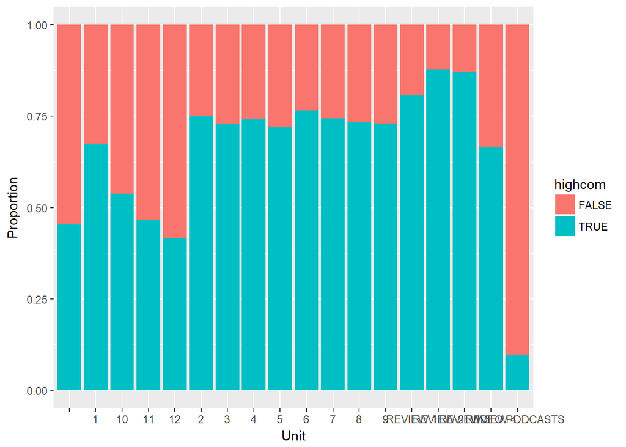

Students with teachers are way better at completing exercises. There should be a special motivational system for students studying on their own (remainders about doing one unit every day, collecting points which users can change for discount on next course).

[figure not shown]

Revision parts are almost always completed from the beginning till the end. Podcast are very rarely finished, almost everyone give up on them. A good option to consider may be changing the length of podcast and make them shorter and/or changing the topics for more interesting/adequate.

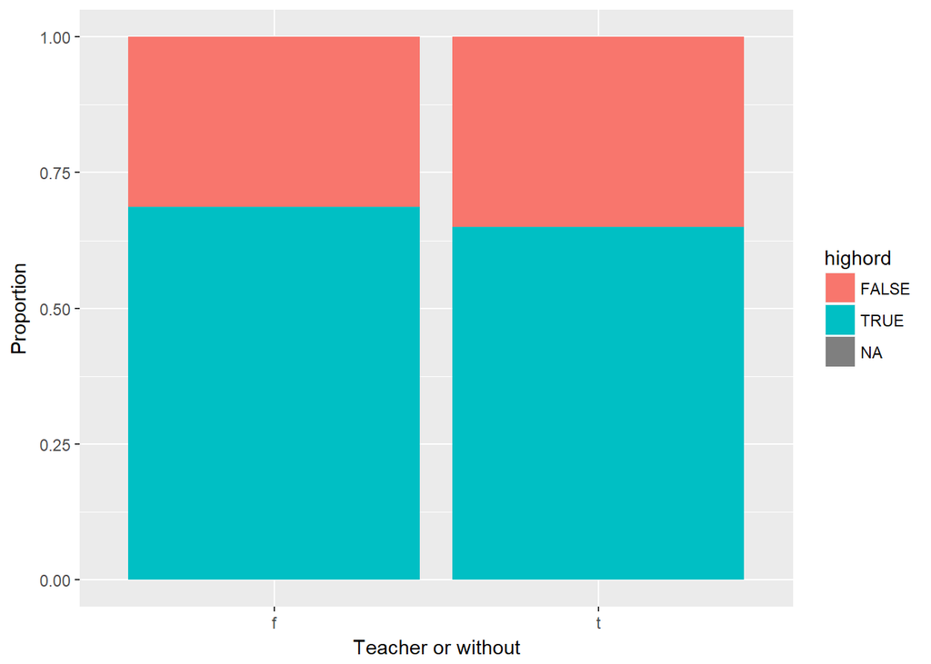

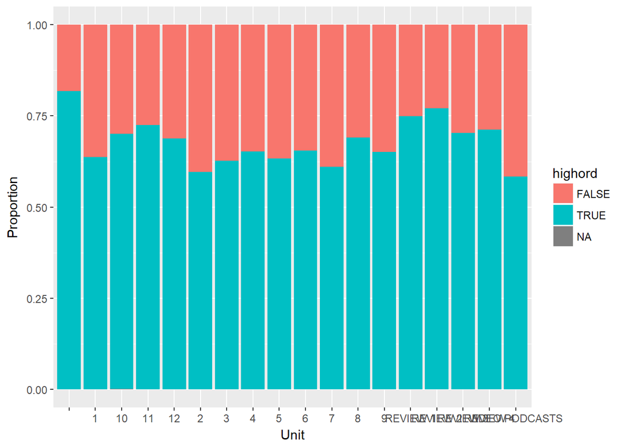

Following the order is more common in revision parts. The order should be well-thought-out in them.

```
##             avg_score  completion    inv_rate
## avg_score   1.0000000  0.10481795 -0.05914160
## completion  0.1048180  1.00000000 -0.08572231
## inv_rate   -0.0591416 -0.08572231  1.00000000
```

We can’t really observe strong correlation between any of the category, but at least we know whether it’s negative or positive. Correlation between average score and completion is positive (the more exercise done, the higher the score is - we can publish this data to encourage students to do more excercises) and between average and order – negative (following the order helps to get higher score). There is also negative correlation between order and completion – the less we follow the order, the less probable is that we’ll finish the unit.